# Estimating a flood inundation probability map

Shengqian Wang & Jiewen Hu

2023-03-22

# 1 Motivation

** VIDEO INTRO: https://youtu.be/UFXsT4QeXbc**

Flood is a natural disaster, which refers to the phenomenon of water flow in rivers, lakes and oceans that rises and exceeds the normal water level. Floods often threaten the safety of areas along rivers, lakesides, and offshore areas, and even cause flooding disasters. Floods are casualties, property damage, and building collapses caused by excessive natural precipitation or untimely drainage. Floods not only flood coastal areas, but also destroy crops, drown livestock, and wash away houses. With the growing impact of climate change and rapid urbanization, it is more important than ever to develop tools that can help cities and communities better understand, predict and prepare for flood events. Estimating flood inundation probability maps is a critical step toward this goal, as it provides insight into high-risk areas and guides urban planning, emergency response, and mitigation strategies.

The proposed algorithm for estimating a flood inundation probability map leverages machine learning techniques, specifically a binomial model, to model the relationship between various geographical and hydrological features and the probability of inundation. The algorithm will use the following predictor variables for the analysis: elevation, distance to river, Flow accumulation, Distance to Steep Slope, Area of Impervious Surface, and slope.

First, we gather and preprocess the data for Calgary, ensuring that all required variables are available and properly formatted. Next, we split the dataset into training and validation sets, which will be used to train and evaluate the binomial model’s performance.

Once the model is trained and validated on the Calgary dataset, we deploy the algorithm on a comparable city - Denver. This involves gathering and preprocessing the required data for Denver, ensuring that the same predictor variables are available in the same format. Using the trained model, we generate probability estimates of inundation for each fishgrid within the Denver dataset.

# 2 Preparation

## 2.1 Setting packages and map theme

Before introducing the code part, we need to load the required packages and set the mapTheme. Thereby setting a cornerstone for the code and visualization of the project.

```r
library(caret)
library(pscl)
library(plotROC)
library(pROC)
library(sf)
library(tidyverse)
library(gridExtra)
library(knitr)
library(kableExtra)
library(tigris)
library(viridis)
```

```r
mapTheme <- theme(plot.title =element_text(size=12),
                  plot.subtitle = element_text(size=8),
                  plot.caption = element_text(size = 6),
                  axis.line=element_blank(),
                  axis.text.x=element_blank(),
                  axis.text.y=element_blank(),
                  axis.ticks=element_blank(),
                  axis.title.x=element_blank(),
                  axis.title.y=element_blank(),
                  panel.background=element_blank(),
                  panel.border=element_blank(),
                  panel.grid.major=element_line(colour = 'transparent'),
                  panel.grid.minor=element_blank(),
                  legend.direction = "vertical",
                  legend.position = "right",
                  plot.margin = margin(1, 1, 1, 1, 'cm'),
                  legend.key.height = unit(1, "cm"), legend.key.width = unit(0.2, "cm"))

plotTheme <- theme(
  plot.title =element_text(size=12),
  plot.subtitle = element_text(size=8),
  plot.caption = element_text(size = 6),
  axis.text.x = element_text(size = 10, angle = 45, hjust = 1),
  axis.text.y = element_text(size = 10),
  axis.title.y = element_text(size = 10),
  panel.background=element_blank(),
  plot.background=element_blank(),
  panel.grid.major=element_line(colour="#D0D0D0",size=.75),
  axis.ticks=element_blank())
```

In order to simplify the coding process, the preliminary work of building the fishnet and adding related data was done in ArcGIS. We mainly use the **Create Fishnet** function to create a fishnet with a size of **300** meters. At the same time, we also extract the data of various related indicators to the lattice through the **Raster to Point** command, and use the **Spatial Join** command to transfer the data to the fishnet.

Here, first load the Calgary fishnet data and the Denver fishnet data that we use for analysis and building predictive models.

```r
inundation <- st_read("fishnet300m_elevation_slope_dist_R_FlowAcc_DistSlp_ImpSf.shp")
Denver <- st_read("Denver_fishnet300m_ImpSf_DistSlp_FlowAcc_distR_elevation.shp")
colnames(Denver)[7] <- "Dist_R"
```

## 2.2 Variables we selected to analyze

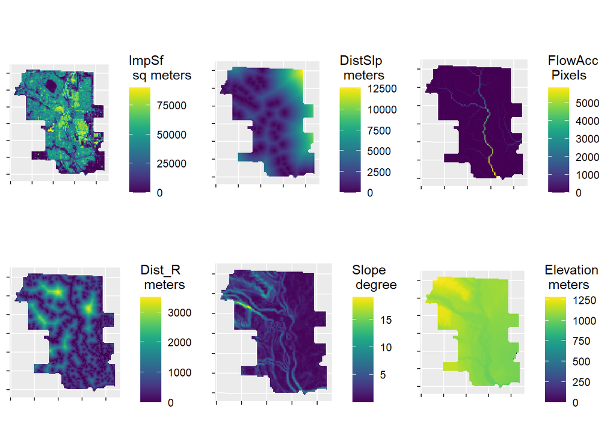

```r
elevation_img<- ggplot() + geom_sf(data = inundation, aes(fill = elevation), color = NA)+labs(fill="Elevation \n meters")+scale_fill_viridis()+theme(axis.text.x = element_blank(),
        axis.text.y = element_blank())
slope_img<- ggplot() + geom_sf(data = inundation, aes(fill = slope), color = NA)+labs(fill="Slope \n degree")+scale_fill_viridis()+theme(axis.text.x = element_blank(),
        axis.text.y = element_blank())
Dist_R_img<- ggplot() + geom_sf(data = inundation, aes(fill = Dist_R), color = NA)+labs(fill="Dist_R \n meters")+scale_fill_viridis()+theme(axis.text.x = element_blank(),
        axis.text.y = element_blank())
FlowAcc_img<- ggplot() + geom_sf(data = inundation, aes(fill = FlowAcc), color = NA)+labs(fill="FlowAcc \n Pixels")+scale_fill_viridis()+theme(axis.text.x = element_blank(),
        axis.text.y = element_blank())
DistSlp_img<- ggplot() + geom_sf(data = inundation, aes(fill = DistSlp), color = NA)+labs(fill="DistSlp \n meters")+scale_fill_viridis()+theme(axis.text.x = element_blank(),
        axis.text.y = element_blank())
ImpSf_img<- ggplot() + geom_sf(data = inundation, aes(fill = ImpSf), color = NA)+labs(fill="ImpSf \n sq meters")+scale_fill_viridis()+theme(axis.text.x = element_blank(),
        axis.text.y = element_blank())

grid.arrange(ImpSf_img,DistSlp_img,FlowAcc_img,Dist_R_img,slope_img,elevation_img,
             ncol=3,
             top = "")
```

## 2.3 Model development and reclassify of all the variables

Extract the above variables from the data for analysis, and divide them according to the values obtained from the test. This part divided the above variables into intervals, and divided them into **0** and **1** categories, which represent whether the conditions we set occur when the inundation occurs.

```r
inundation %>% as.data.frame() %>%
    select(inundation,elevation, slope, Dist_R, FlowAcc, DistSlp, ImpSf) %>%
    pivot_longer(cols = -inundation)
```

```r
##inundationA <-
      ##mutate(inundationA, inundation = ifelse(inundation > 0, 1, 0))
inundation <-
      mutate(inundation, elevation = ifelse(elevation < 1095, 1, 0))
inundation <-
      mutate(inundation, Dist_R = ifelse(Dist_R < 400, 1, 0))
inundation <-
      mutate(inundation, FlowAcc = ifelse(FlowAcc > 3, 1, 0))
inundation <-
      mutate(inundation, DistSlp = ifelse(DistSlp > 2400, 1, 0))
inundation <-
      mutate(inundation, ImpSf = ifelse(ImpSf > 46000, 1, 0))
inundation <-
      mutate(inundation, slope = ifelse(slope > 2.5, 1, 0))
```

```r
Denver <-
      mutate(Denver, elevation = ifelse(elevation < 1095, 1, 0))
Denver <-
      mutate(Denver, Dist_R = ifelse(Dist_R < 400, 1, 0))
Denver <-
      mutate(Denver, FlowAcc = ifelse(FlowAcc > 3, 1, 0))
Denver <-
      mutate(Denver, DistSlp = ifelse(DistSlp > 2400, 1, 0))
Denver <-
      mutate(Denver, ImpSf = ifelse(ImpSf > 46000, 1, 0))
Denver <-
      mutate(Denver, slope = ifelse(slope > 2.5, 1, 0))
```

Then use bar plots showing variables. It’s easy to identify the amount of each variables in preset conditions.

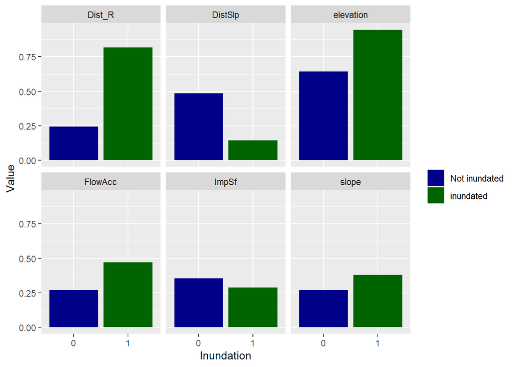

```r
inundationPlotVariables <-
  inundation %>%
  as.data.frame() %>%
  select(inundation,elevation, slope, Dist_R, FlowAcc, DistSlp, ImpSf) %>%
  gather(variable, value, -inundation)

ggplot(inundationPlotVariables %>%
         group_by(inundation, variable) %>%
         summarize(mean = mean(value))) +
     geom_bar(aes(as.factor(inundation),
                  mean,
                  fill=as.factor(inundation)),
              stat="identity") +
     facet_wrap(~variable) +
     scale_fill_manual(values = c("dark blue", "dark green"),
                      labels = c("Not inundated","inundated"),
                      name = "") +
    labs(x="Inundation", y="Value")
```

# 3 Prediction model development

## 3.1 Binomial model establishment

Select relevant variables discussed above for both Calgary dataset and also Denver dataset.

```r
inundation <-
  inundation %>%
  select(inundation,elevation, slope, Dist_R, FlowAcc, DistSlp, ImpSf)
```

```r
Denver <-
  Denver %>%
  select(elevation, slope, Dist_R, FlowAcc, DistSlp, ImpSf)
#Add Index Id
inundation$Id <- 1:nrow(inundation)
```

### 3.1.1 Partition training and test sets

The first stop to train a model is to seperate test set and train set, which is for the later cross validation and exam use.

```r
set.seed(3456)
trainIndex <- createDataPartition(inundation$inundation, p = .70,
                                  list = FALSE,
                                  times = 1)
inundationATrain <- inundation[ trainIndex,]
inundationATest  <- inundation[-trainIndex,]
```

### 3.1.2 Binomial model training

This part of code trains a model to predict inundation based on relevant variables using the split Calgary training data set.

```r
inundationModel <- glm(inundation ~ .,
                    family="binomial"(link="logit"), data = inundationATrain %>%
                                                            as.data.frame() %>%
                                                            select(-geometry, -Id))
```

## 3.2 Model summary, analysis, and validation

```r
summary(inundationModel)
```

```
##
## Call:
## glm(formula = inundation ~ ., family = binomial(link = "logit"),
##     data = inundationATrain %>% as.data.frame() %>% select(-geometry,
##         -Id))
##
## Deviance Residuals:
##     Min       1Q   Median       3Q      Max
## -1.7932  -0.4142  -0.1570  -0.1056   3.7496
##
## Coefficients:
##             Estimate Std. Error z value Pr(>|z|)
## (Intercept)  -4.7983     0.2113 -22.710  < 2e-16 ***
## elevation     2.2513     0.1901  11.841  < 2e-16 ***
## slope         0.4085     0.1142   3.575  0.00035 ***
## Dist_R        2.7410     0.1141  24.029  < 2e-16 ***
## FlowAcc       0.6476     0.1032   6.278 3.44e-10 ***
## DistSlp      -2.6390     0.1297 -20.353  < 2e-16 ***
## ImpSf         0.1341     0.1123   1.195  0.23221
## ---
## Signif. codes:  0 '***' 0.001 '**' 0.01 '*' 0.05 '.' 0.1 ' ' 1
##
## (Dispersion parameter for binomial family taken to be 1)
##
##     Null deviance: 4412.7  on 5543  degrees of freedom
## Residual deviance: 2665.8  on 5537  degrees of freedom
## AIC: 2679.8
##
## Number of Fisher Scoring iterations: 7
```

### 3.2.1 Histogram of classProbs

Running a histogram of classprobs shows the frequency of each level of probability that the inundation occurs.

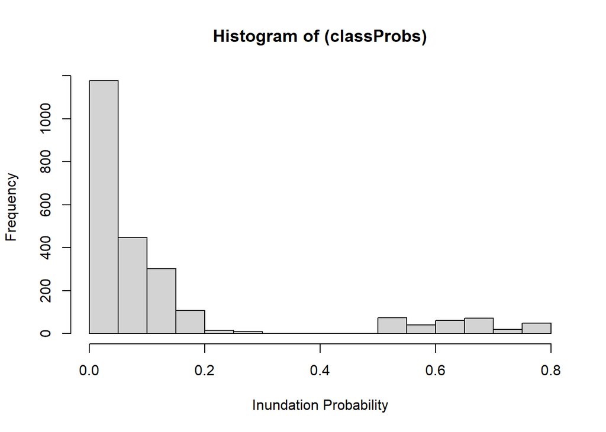

```r
classProbs <- predict(inundationModel, inundationATest, type="response")

hist((classProbs), xlab = "Inundation Probability")
```

```r
testProbs <- data.frame(obs = as.numeric(inundationATest$inundation),
                        pred = classProbs)
```

### 3.2.2 Confusion Matrix

Confusion Matrix shows the accuracy of this model. There are four posible result in this part which are: True Positive: Model predicts inundation and it happens True Negative: Model predicts no inundation and it does not happen False Positive: Model predicts inundation and it does not happen False Negative: Model predicts no inundation and it happens

```r
testProbs$predClass  = ifelse(testProbs$pred > .5 ,1,0)

caret::confusionMatrix(reference = as.factor(testProbs$obs),
                       data = as.factor(testProbs$predClass),
                       positive = "1")
```

```
## Confusion Matrix and Statistics
##
##           Reference
## Prediction    0    1
##          0 1937  122
##          1   87  229
##
##                Accuracy : 0.912
##                  95% CI : (0.8999, 0.9231)
##     No Information Rate : 0.8522
##     P-Value [Acc > NIR] : < 2e-16
##
##                   Kappa : 0.6356
##
##  Mcnemar's Test P-Value : 0.01868
##
##             Sensitivity : 0.65242
##             Specificity : 0.95702
##          Pos Pred Value : 0.72468
##          Neg Pred Value : 0.94075
##              Prevalence : 0.14779
##          Detection Rate : 0.09642
##    Detection Prevalence : 0.13305
##       Balanced Accuracy : 0.80472
##
##        'Positive' Class : 1
##
```

### 3.2.3 ROC Curve

ROC curve (receiver operating characteristic curve) is a graph showing the performance of a classification model at all classification thresholds.

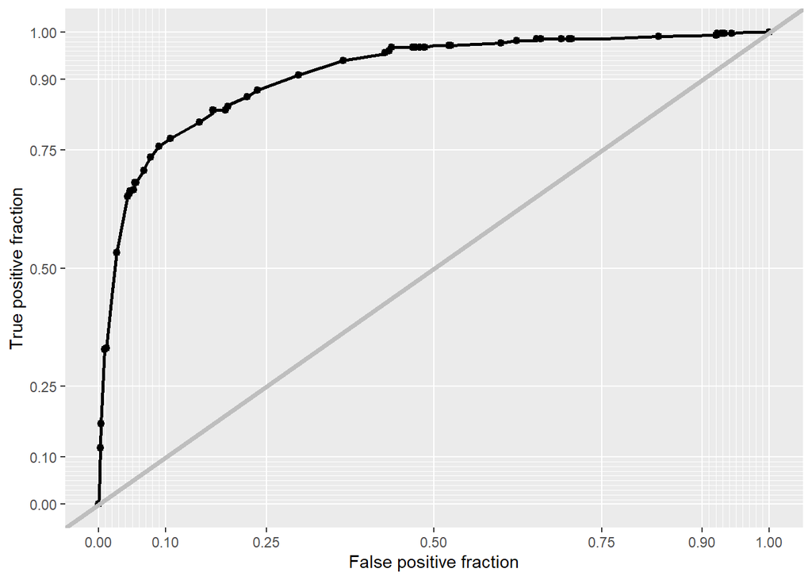

```r
ggplot(testProbs, aes(d = obs, m = pred)) +
  geom_roc(n.cuts = 50, labels = FALSE) +
  style_roc(theme = theme_grey) +
  geom_abline(slope = 1, intercept = 0, size = 1.5, color = 'grey')
```

```r
auc(testProbs$obs, testProbs$pred)
```

```
## Area under the curve: 0.9115
```

### 3.2.4 Cross Validation

By testing and cross-validating the model on the original large data set, the results can show the generalization level of the model, thereby testing whether it is overfitting or has the potential to be applied in the real world.

```r
ctrl <- trainControl(method = "cv",
                     number = 100,
                     p = 0.7,
                     savePredictions = TRUE)

cvFit <- train(as.factor(inundation) ~ .,  data =inundation %>%
                                                as.data.frame() %>%
                                                select(-geometry, -Id),
               method="glm", family="binomial",
               trControl = ctrl)

cvFit
```

```
## Generalized Linear Model
##
## 7919 samples
##    6 predictor
##    2 classes: '0', '1'
##
## No pre-processing
## Resampling: Cross-Validated (100 fold)
## Summary of sample sizes: 7840, 7840, 7840, 7840, 7839, 7840, ...
## Resampling results:
##
##   Accuracy   Kappa
##   0.9085601  0.6134997
```

### 3.2.5 Model accuracy

This graph shows the prediction result gathers at a accuracy of around 0.9.

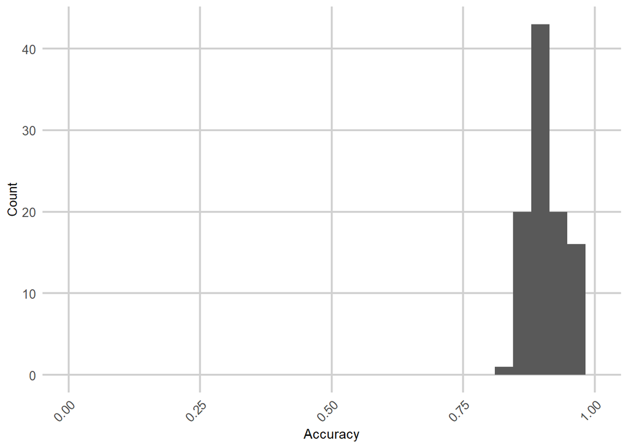

```r
ggplot(as.data.frame(cvFit$resample), aes(Accuracy)) +
  geom_histogram() +
  scale_x_continuous(limits = c(0, 1)) +
  labs(x="Accuracy",
       y="Count")+
  plotTheme
```

# 4 Mapping of results

```r
allPredictions <-
  predict(cvFit, inundation, type="prob")[,2]

inundation <-
  cbind(inundation,allPredictions) %>%
  mutate(allPredictions = round(allPredictions * 100))

Predictions <-
  predict(cvFit, Denver, type="prob")[,2]

Denver <-
  cbind(Denver,Predictions) %>%
  mutate(Predictions = round(Predictions * 10000))
```

## 4.1 Mapping of Confusion Matrix

This part shows the Confusion Matrix at map. The spatial distribution of Matrix and the spatial display results prove that the model is still somewhat conservative in predicting inundation, and the prediction ability along the river is insufficient.

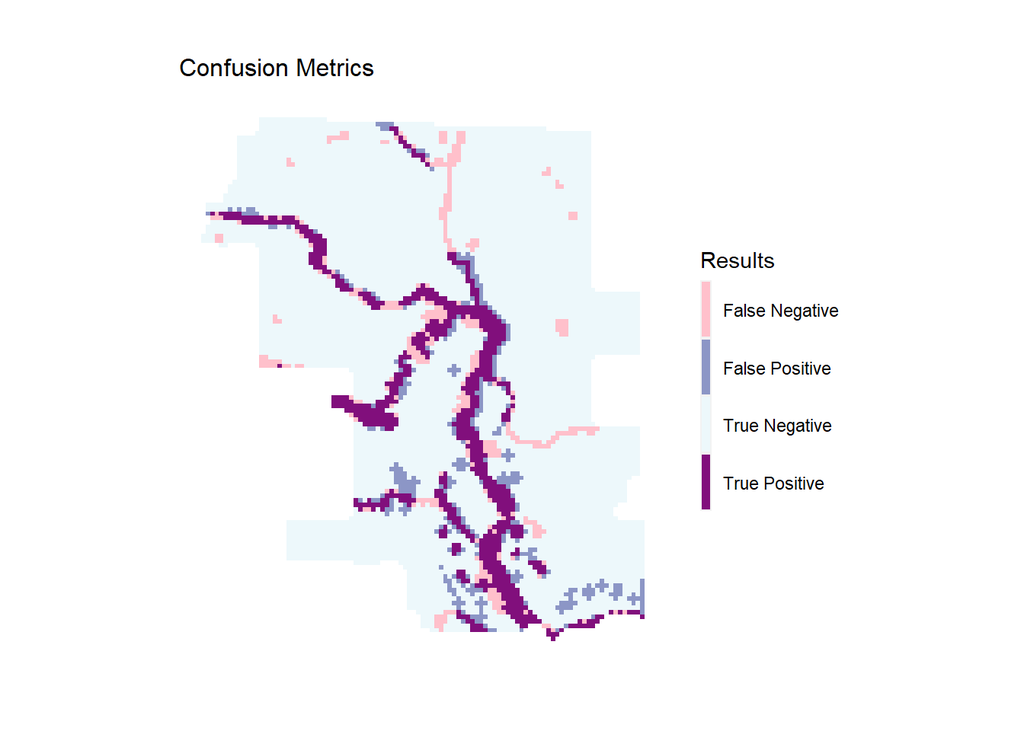

```r
inundation %>%
  mutate(CMResult=case_when(allPredictions <= 50 & inundation==0 ~ "True Negative",
                              allPredictions > 50 & inundation==1 ~ "True Positive",
                              allPredictions <= 50 & inundation==1 ~ "False Negative",
                              allPredictions > 50 & inundation==0 ~ "False Positive")) %>%
  ggplot()+
  geom_sf(aes(fill = CMResult), color = "transparent")+
  scale_fill_manual(values = c("pink","#8c96c6","#edf8fb","#810f7c"), name="Results")+
  labs(title="Confusion Metrics") +
  mapTheme
```

## 4.2 Mapping of Prediction Result in Calgary

Using this model to predict the inundation map of Calgary.

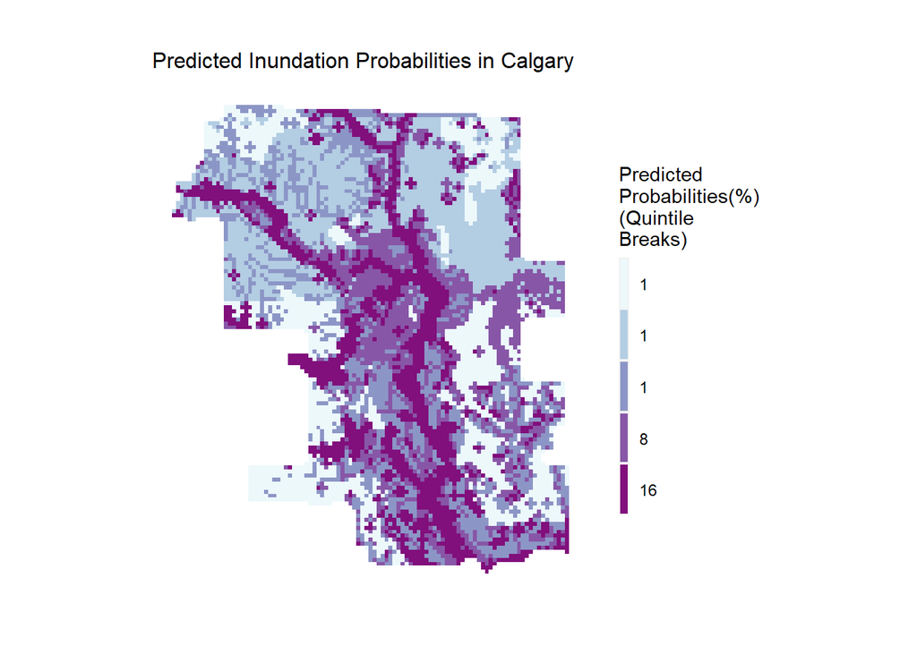

```r
 ggplot() +
    geom_sf(data=inundation, aes(fill=factor(ntile(allPredictions,5))),
            colour=NA) +
    scale_fill_manual(values = c("#edf8fb","#b3cde3","#8c96c6","#8856a7","#810f7c"),
                      labels=as.character(quantile(inundation$allPredictions,
                                                 c(0.1,.2,.4,.6,.8),
                                                 na.rm=T)),
                      name="Predicted\nProbabilities(%)\n(Quintile\nBreaks)") +
  mapTheme +
  labs(title="Predicted Inundation Probabilities in Calgary")
```

## 4.3 Mapping of Prediction Result in Denver

Using this model to predict inundation in Denver. It’s clear the model predict some flooding event on the map, but there are still some potential for this model to improve.

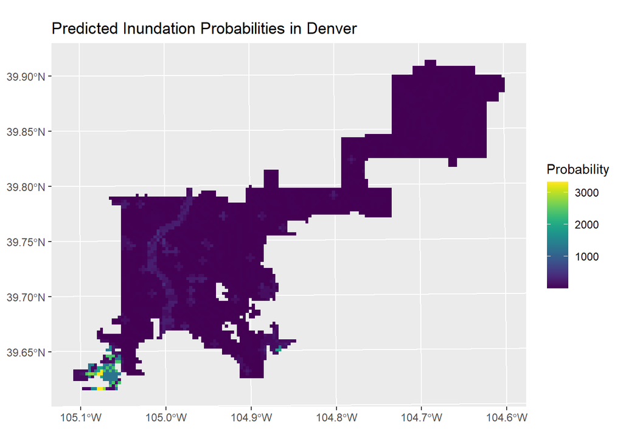

```r
ggplot() +
    geom_sf(data=Denver, aes(fill=(Predictions)), colour=NA) +
  scale_fill_viridis(name = "Probability")+
  labs(title="Predicted Inundation Probabilities in Denver")
```

# 5 Project summary

This model was developed to estimate flood inundation probabilities for the city of Calgary, using predictor variables such as elevation, distance to river, flow accumulation, distance to steep slope, area of impervious surface, and slope. The model was trained and validated on the Calgary dataset and subsequently deployed to predict inundation probabilities for the city of Denver.

The results of the model were satisfactory but revealed a high rate of false negatives, which indicates that the model might have underestimated the probability of inundation in certain areas. This could be due to various factors, such as limitations in the predictor variables, the model’s sensitivity to specific regional factors, or the need for additional data to improve the model’s accuracy.

When applying the model to the Denver dataset, the performance was not as good as in the Calgary dataset. This could be attributed to differences in the two cities’ geographical, hydrological, and urban features, which might not be adequately captured by the model. It is possible that the model requires further calibration or additional predictor variables to better adapt to the unique characteristics of Denver.

But this can be a very good tool and start point for policy makers on analyzing local condition and risk of inundation especially in the cities with similar context of Calgary.